# Potential Hydrochemographs

LAR

4/22/2022

## Niwot Ridge LTER

These data are from the stream outlet of Green Lake 4. The winter chemistry data is collected beneath the ice in the lake. During 2014, the discharge data deviates from the other streams and the typical seasonal pattern. The lead technician for Niwot Ridge LTER reported nothing obvious on the ground that would casue an error. So it is possible that the discharge data from 2014 are either real or there could have been some sort of sensor issue.

### Hydrochemographs!!!

Stoichiometric timeseries - if we decide we want to use any of these

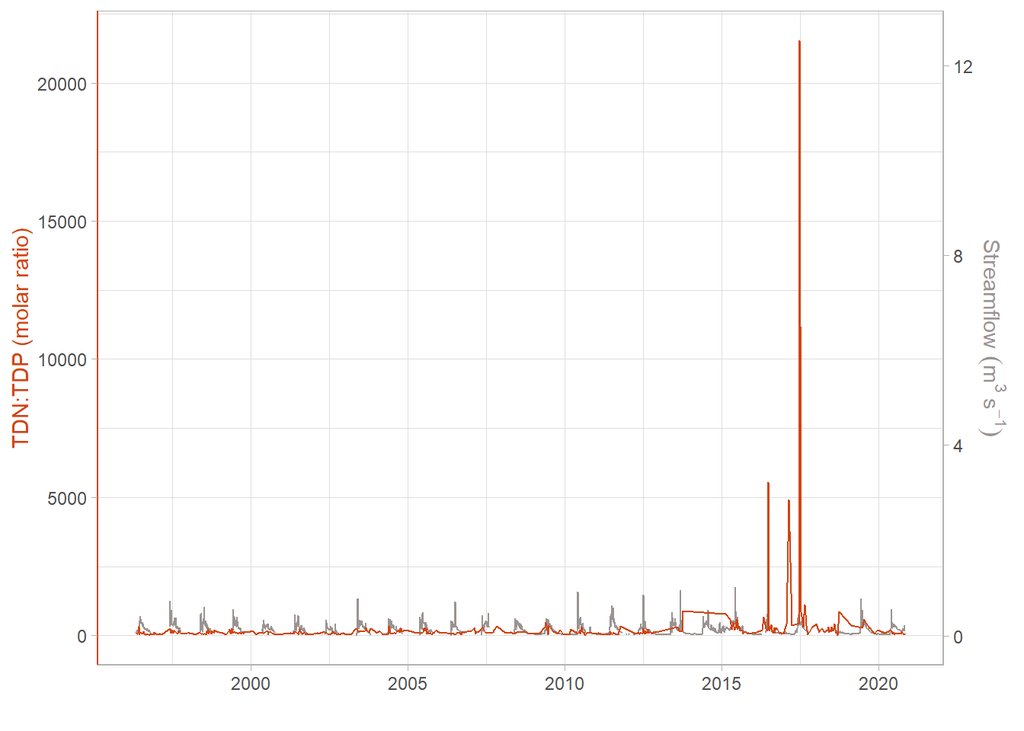

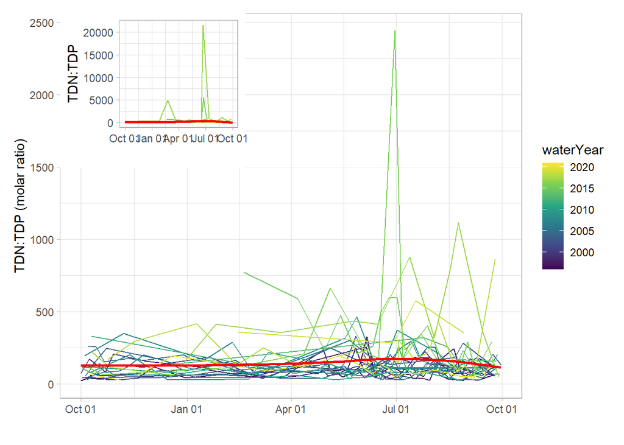

Here is a figure with TDN and TDP and streamflow…

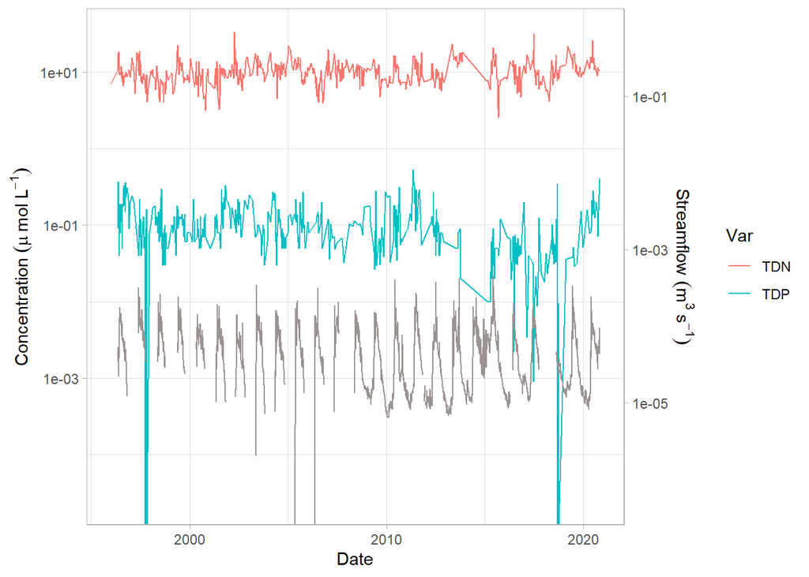

Here are the nitrate, TDN, and TDP hydrochemographs. Note the nitrate units are the worst possible units anyone could provide with data.

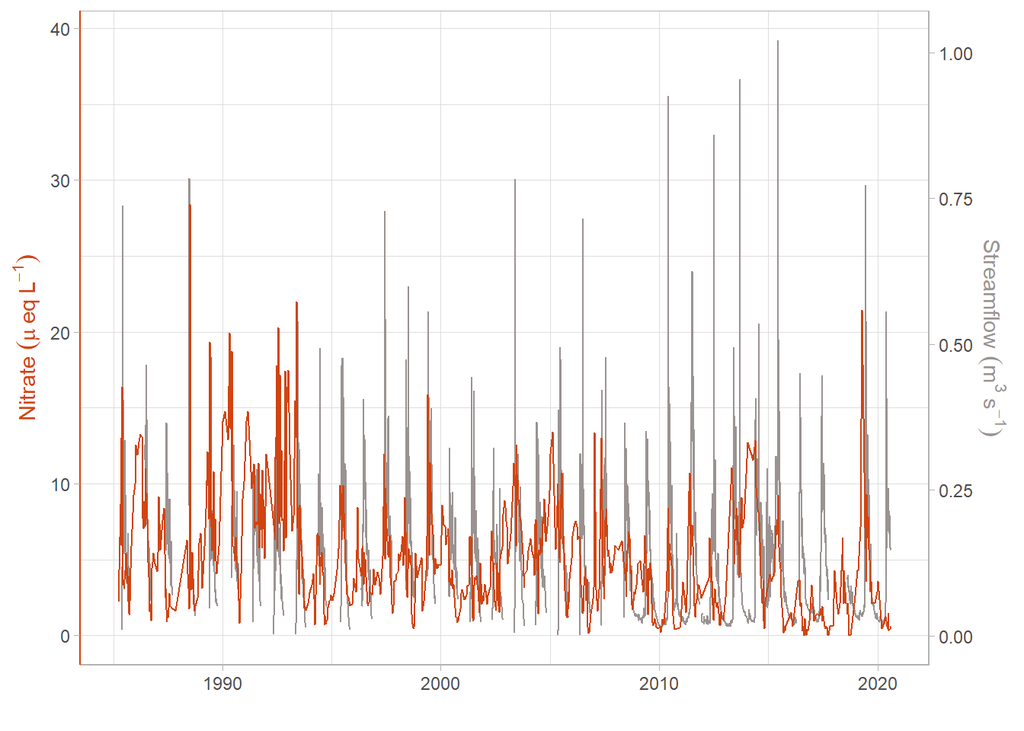

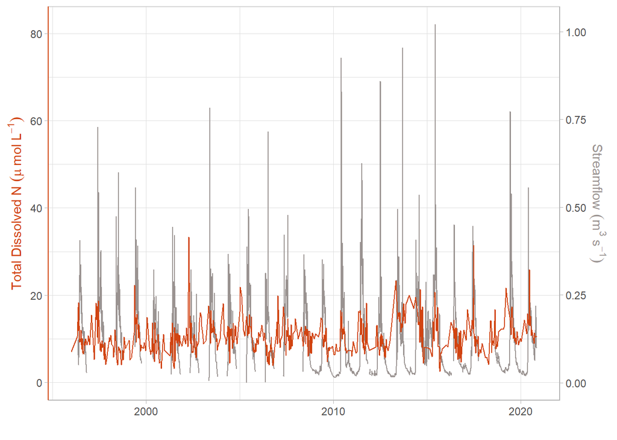

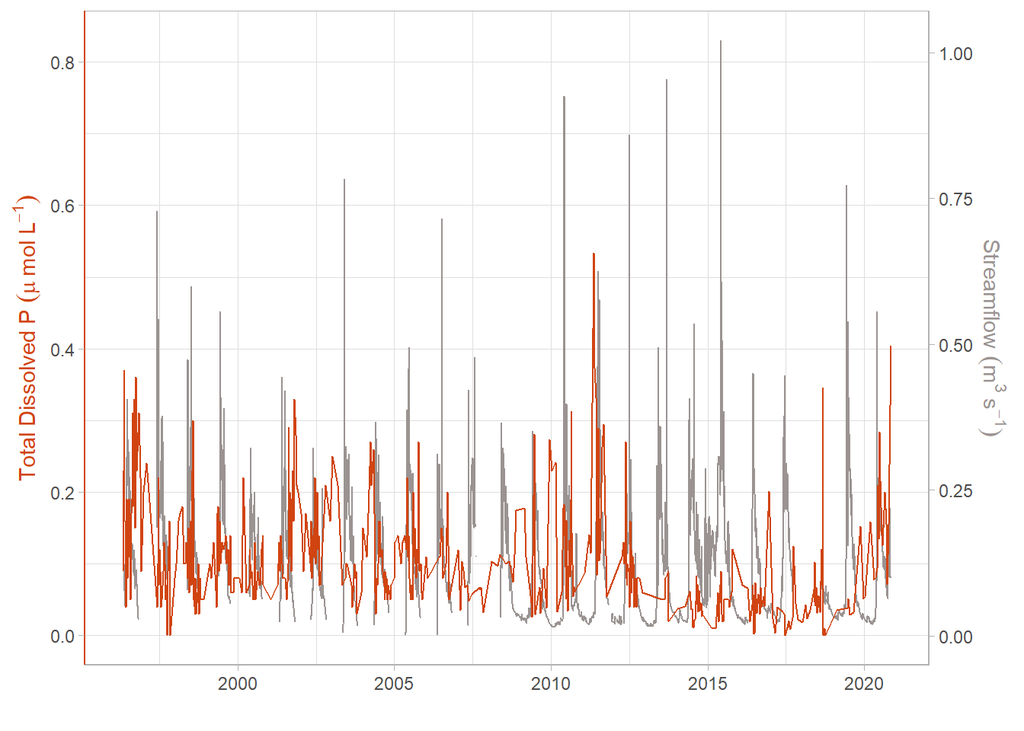

A few more Green Lake 4 outlet water year figures. - Note: I just used the “loess” function in ggplot to make that red trend line.

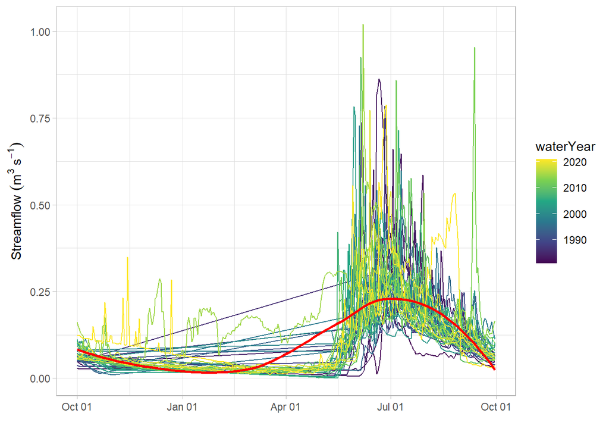

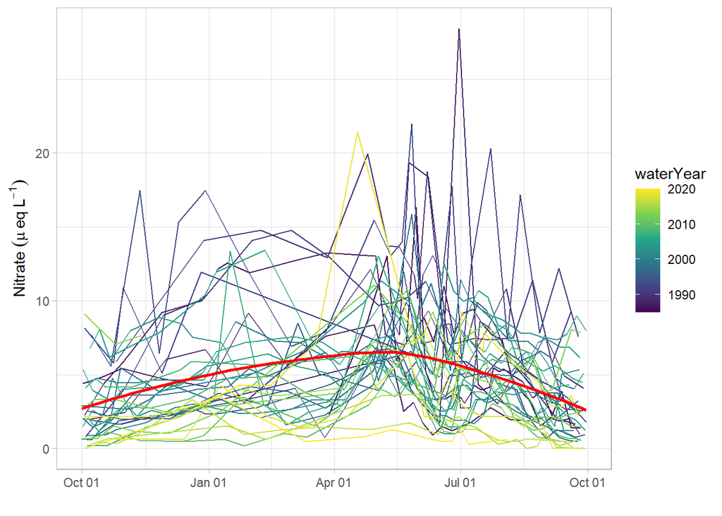

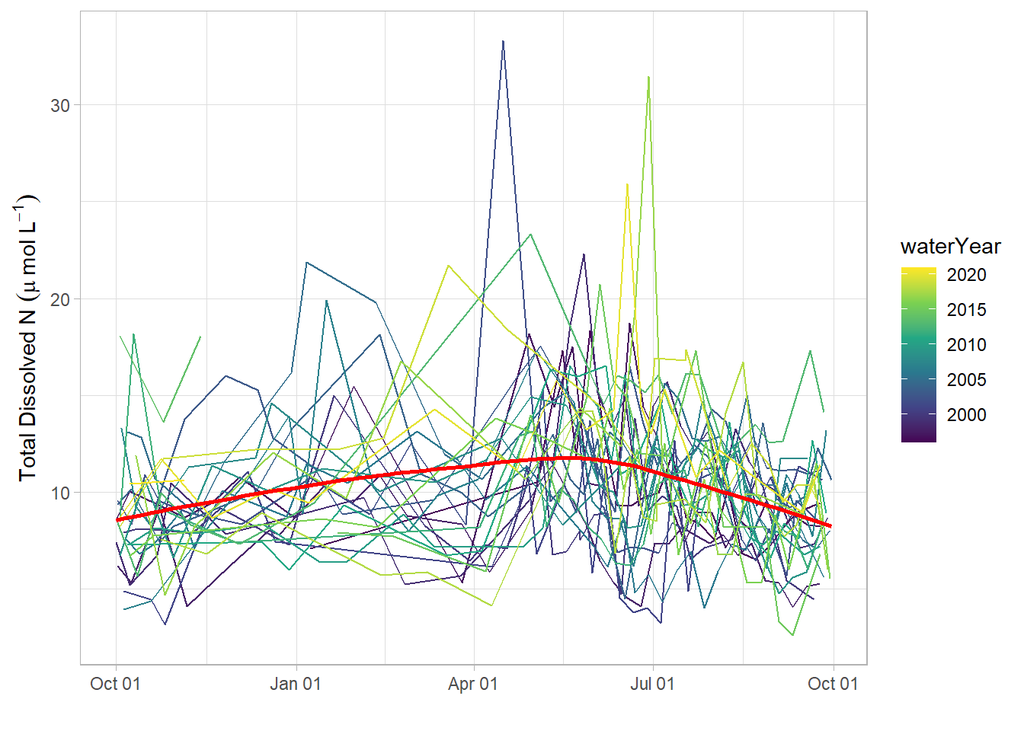

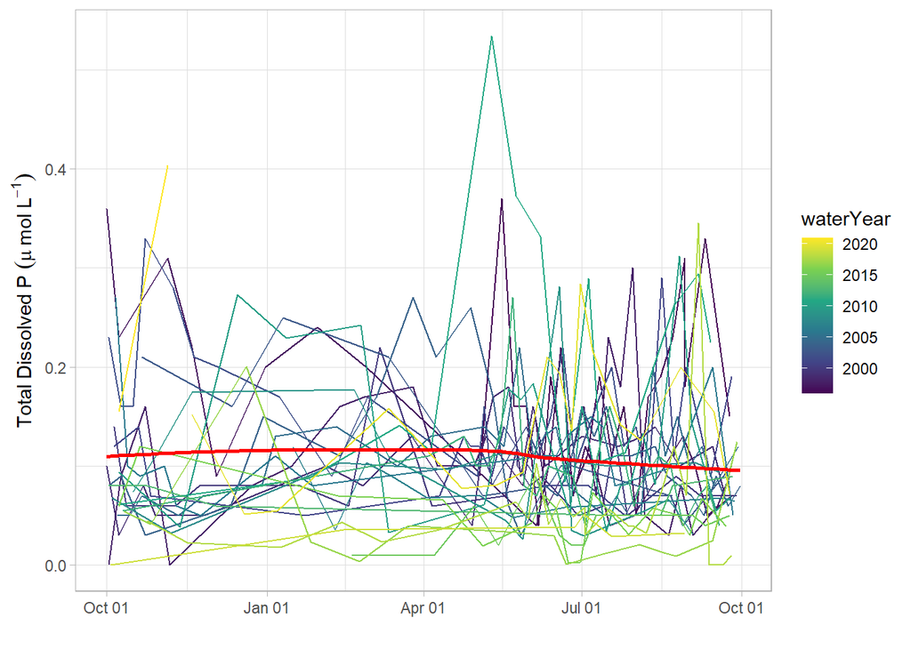

## Loch Vale

These data are from the stream outlet of Loch Vale and were downloaded from USGS using the dataReterieval package in R (De Cicco et al., 2021).

### More beautiful hydrochemographs!!!

We have good nitrate data to create hydrochemographs from this site. Here is the nitrate hydrochemograph.

Phosphate data were often below detection limit :(

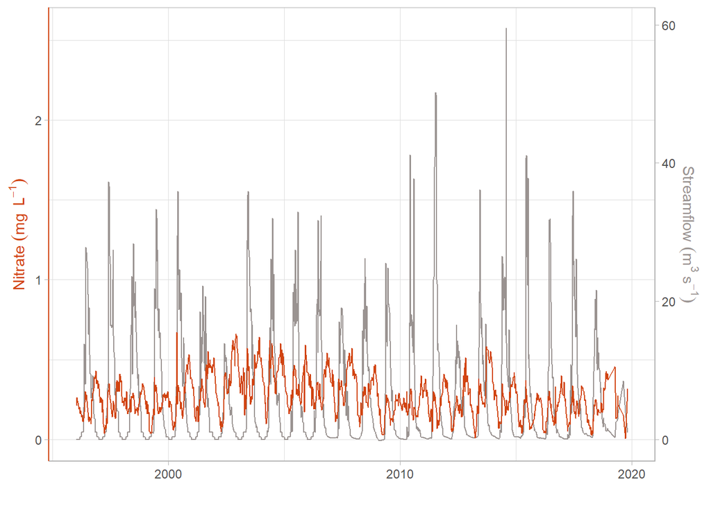

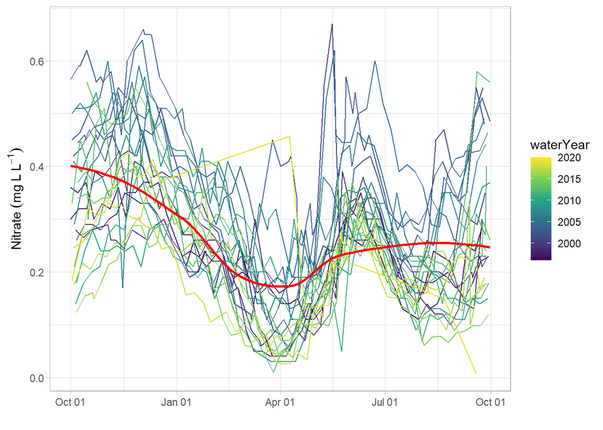

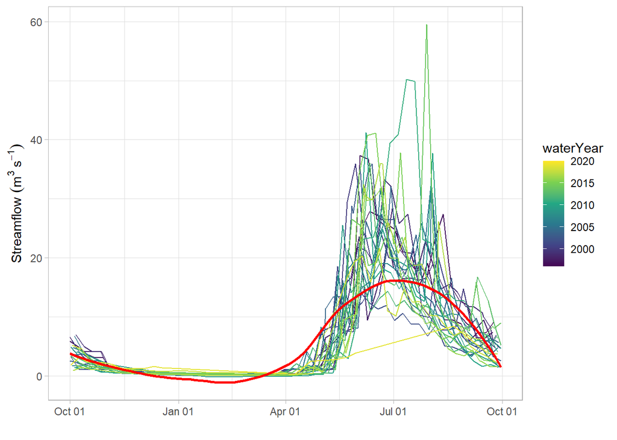

## Data Sources

Caine, N., J. Morse, and Niwot Ridge LTER. 2022. Streamflow for Green Lake 4, 1981 - ongoing. ver 15. Environmental Data Initiative. https://doi.org/10.6073/pasta/ff6f7947279eeeeca851baed6cd6f41a (Accessed 2022-04-22).

Caine, T. 2021. Stream water chemistry data for Green Lake 4, 1982 - ongoing. ver 12. Environmental Data Initiative. https://doi.org/10.6073/pasta/277121f0334757746d9d52ce2c2e82ab (Accessed 2022-04-22).

De Cicco, L.A., Hirsch, R.M., Lorenz, D., Watkins, W.D., 2021, dataRetrieval: R packages for discovering and retrieving water data available from Federal hydrologic web services, doi:10.5066/P9X4L3GE

“Logistical support and/or data were provided by the USGS supported Loch Vale Watershed Long-term Ecological Research and Monitoring program and Colorado State University.”